# Ford GoBike Analysis

## by Adriana Zurawska

## Investigation Overview

> In my presentation I will discuss the Ford GoBike user population and its behaviour in connection to the service development over time. The most interesting aspects in my analysis were: user demographics and user behavior. In my presentation I will focus on discussing the user profile - who is using GoBike and how this can be used for the further development of the service.

## Dataset Overview

> The dataset consists of GoBike ride data collected over 18 months. The dataset holds data on bike id, user birth year, gender, journey start point, journey end point, start and end time and date of the trip.

## When the trips are longest ?

> Duration of the ride can help to determine how the bikes are used.

> > The longest rides take place on Thursdays and Fridays. This is an interesting observation and maybe it is connected with more traffic on those days or some other events that can influence the speed of the ride.

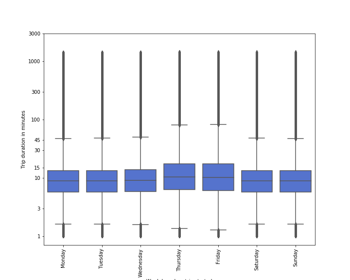

```python
Image(filename='ride_duration_dayofweek.png')
```

## When the bikes are used?

The most busy time of the day is in the morning between 7 and 9 am and by the evening between 5 and 7 pm. This points out towards the cycle-to-work sheme and it is evident that majority of users is taking the bike to commute to and from work. This is a great find that GoBike is used to help professionals commute to work. This user group seems to be the root of the service, not the leisure bikers.

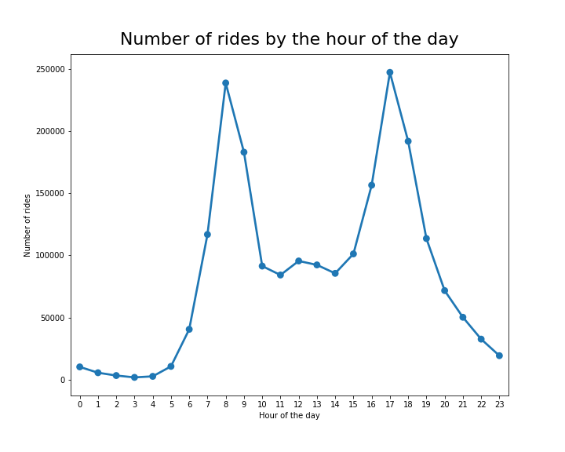

```python
Image(filename='rides_by_hour.png')
```

## How old are users?

> The average user age is 35.47 and majority of the users are between 27 and 41 years old (green box). The boxplot whiskers are showing the minimum and maximum user age values, while the black dots are the outlying points outside the ususal data. The most active age group consists of young adults and professionals.

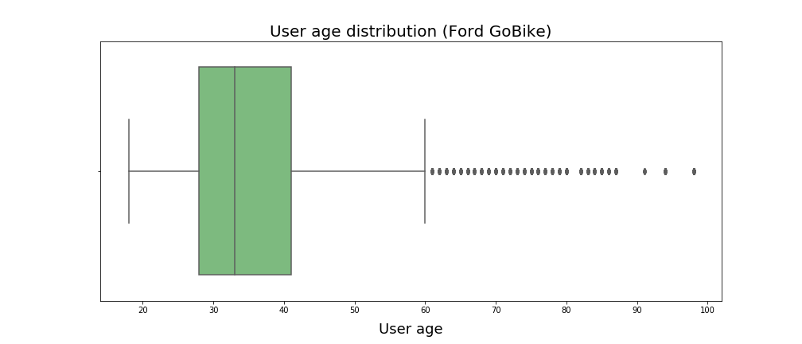

```python
Image(filename='age_boxplot2.png')
```

Diving into more detail in regard to user age distribution, I wan't to discuss the user age groups egnagement over time.

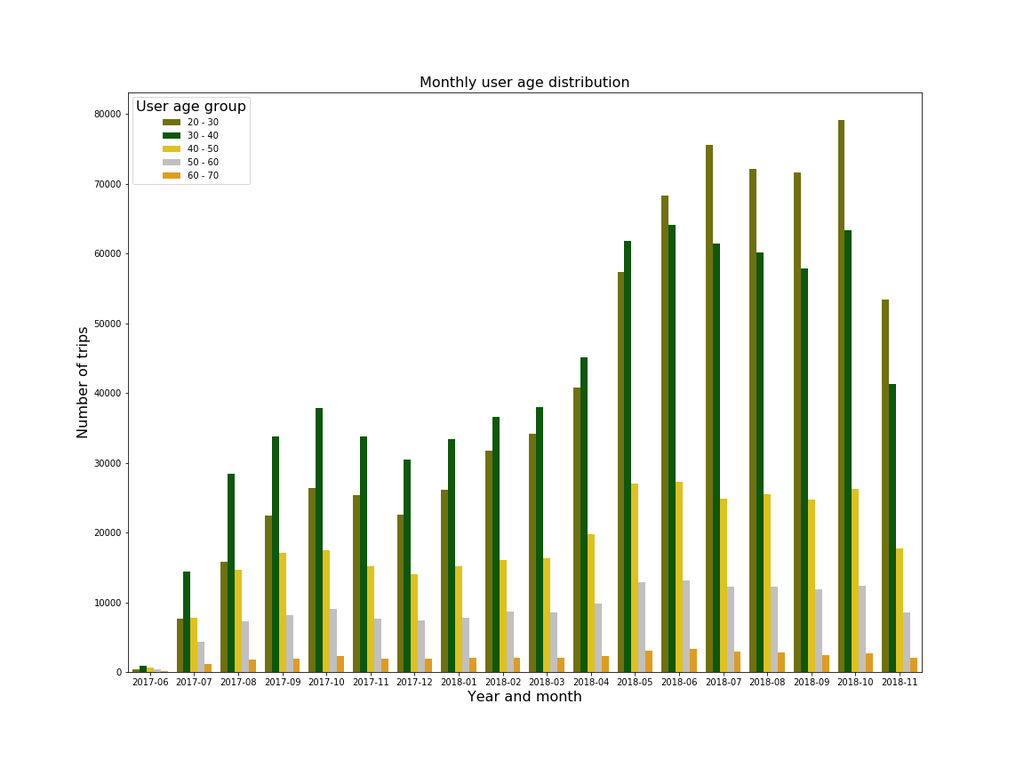

```python
Image(filename='user_age_monthly.png')
```

## Which gender uses Gobike the most?

> Majority of the GoBike users are males. This insight might be helpful for the future investigation to invite more female users to use the service. Maybe the bicycles are too heavy for women? Maybe some females are having small children and the bicycle doesn't have the child seat?

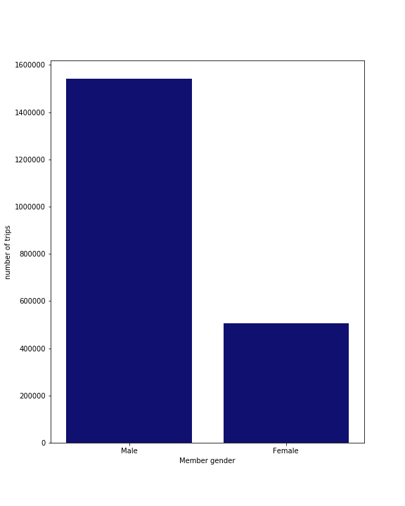

```python
Image(filename='member_gender.png')
```

## User type and weekday trend

> There seem to be significantly less Subscribers towards end of the week: in Thursday and Friday, and the most Customers made trips on Thursday. This is surprising discovery as I would assume that there are more Customers during weekends (weekend trips with kids, cycling with friends) when on weekdays I would expect the same high amount of Subscribers throughout the week (cycling to work).

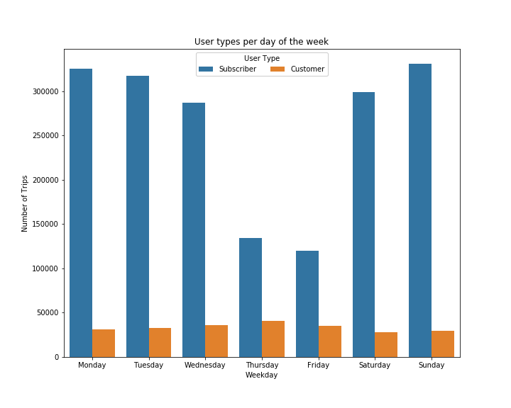

```python
Image(filename='user_type_dayoftheweek.png')
```

## User gender and weekday trend

> The user gender shows the same trend as user type: there is a drop in number of trips mid-week (Thursday and Friday) and number of trips is rising again during weekends.

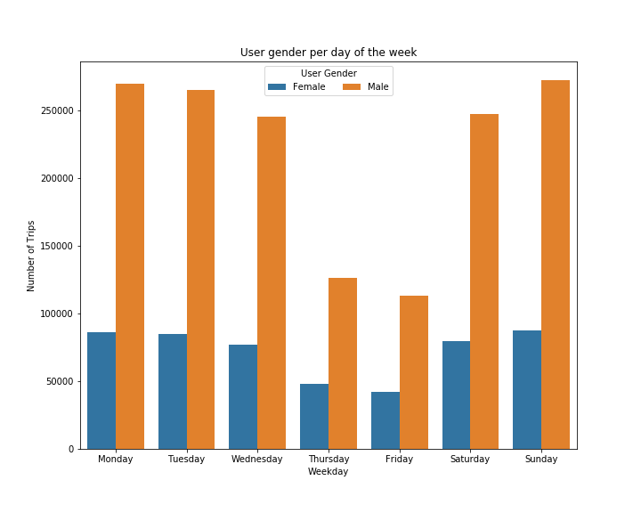

```python
Image(filename='user_gender_dayofweek.png')
```

## Subscribers and Customers habits

> There is a difference in the weekly behavior of those two groups. Customers usually take longer trips than Subscribers. The longest trips mabe by Customers take place on Thursdays and Fridays. I think this is a very interesting observation.

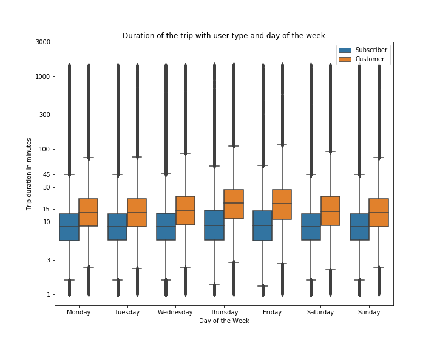

```python
Image(filename='duration_usertype_dayofweek.png')
```